# Biomedical Engineering - Miniproject: Data explotarion

In this project data from The Global Terrorism Database (GTD) - open-source database including information on terrorist attacks around the world from 1970 through 2017, was used. The task was to think of 5 questions one could have after seeing the data.

### Loading and reparing the data

In the first step all needed libraries were imported and data was loaded using pandas read_csv function.

```python
import numpy as np
import pandas as pd
import csv
import pycountry
import plotly.plotly as py
import plotly.graph_objs as go
from plotly.offline import download_plotlyjs, init_notebook_mode, plot, iplot
import matplotlib.pyplot as plt
import seaborn as sns

terror = pd.read_csv('globalterrorismdb_0718dist.csv', encoding='ISO-8859-1', low_memory=False)
terror['casualties'] = terror['nkill'] + terror['nwound']
terror.rename(columns = {'iyear': 'year', 'targtype1_txt' : 'target', 'attacktype1_txt' : 'attack_type', 'weaptype1_txt' : 'weapon'}, inplace = True)
terror = terror[['year','country', 'country_txt', 'casualties','target', 'attack_type', 'weapon', 'gname']]
```

### 1. TOP10 countries with the highest number of casualties

To have a quick overlook on what parts of the world are mostly affected by terrorist attacks a map was created. Only 10 countries with highest number of casualties (number of people killed, but also those who were wounded) were taken into consideration and showed on the map. To create the map using plotly, country codes were needed. They were imported from pycountry library and assigned to countries' names.

```python
highest_terror = terror.groupby('country_txt')['casualties'].sum().sort_values(ascending=False).head(10)
df = highest_terror.reset_index()
input_countries = df['country_txt']

countries = {}
for country in pycountry.countries:
    countries[country.name] = country.alpha_3

codes = [countries.get(country, 'SYR') for country in input_countries]
df['codes'] = codes

data = dict(
        type = 'choropleth',
        locations = df['codes'],
        z = df['casualties'],
        text = df['country_txt'],
        colorbar = {'title' : 'Countries and casualities'},
      )
layout = dict(
    title = 'Countries and casualities',
    geo = dict(
        showframe = False,
        projection = {'type':'mercator'}
    )
)

init_notebook_mode(connected=True)

choromap = go.Figure(data = [data],layout = layout)
iplot(choromap)
```

[interactive chart not shown]

### 2. Number of attacks through years

To see the trend in the number of attacks throughout the years, a graph was made using seaborn countplot.

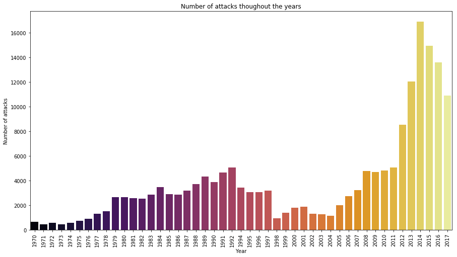

```python
plt.subplots(figsize=(15,8))
sns.countplot('year', data=terror, palette='inferno', order=terror['year'].value_counts().index.sort_values())
plt.xticks(rotation=90)
plt.title('Number of attacks thoughout the years')
plt.xlabel('Year')
plt.ylabel('Number of attacks')
plt.show()
```

### 3. Favourite types of attack and weapon

To answer which types of attack are the most common ones pandas' value_counts funtion was used and the outcome was presented on seaborn countplot. In case of weapons the graph made using barplot from seaborn was used to show the corellation between number of casulaties and chosen weapon.

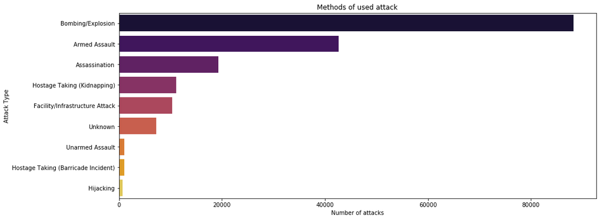

```python
plt.subplots(figsize=(15,6))
sns.countplot(y = 'attack_type',data=terror,orient = 'v', palette='inferno',order=terror['attack_type'].value_counts().index)
plt.title('Methods of used attack')
plt.ylabel('Attack Type')
plt.xlabel('Number of attacks')

plt.show()
```

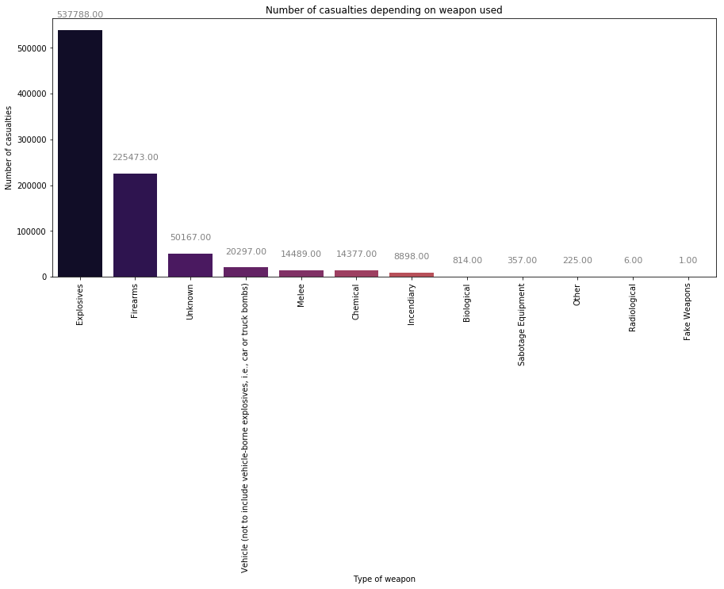

```python
terror_weapon = terror.groupby('weapon')['casualties'].sum().sort_values(ascending=False)
df_weapon = terror_weapon.reset_index()
plt.subplots(figsize=(15,6))
ax = sns.barplot(x = df_weapon['weapon'],y=df_weapon['casualties'],palette='inferno')
plt.title('Number of casualties depending on weapon used')
plt.ylabel('Number of casualties')
plt.xlabel('Type of weapon')
plt.xticks(rotation=90)

for p in ax.patches:
             ax.annotate("%.2f" % p.get_height(), (p.get_x() + p.get_width() / 2., p.get_height()),
                 ha='center', va='center', fontsize=11, color='gray', xytext=(0, 20),
                 textcoords='offset points')
plt.show()
```

### 4. TOP5 dangerous terrorist groups

```
                                         gname  casualties
0                                      Unknown    313997.0
1  Islamic State of Iraq and the Levant (ISIL)     58223.0
2                                      Taliban     54459.0
3                                     Al-Qaida     28340.0
4      Liberation Tigers of Tamil Eelam (LTTE)     20859.0
5                                   Boko Haram     20305.0
```

[figure not shown]

```python
terror_groups = terror.groupby('gname')['casualties'].sum().sort_values(ascending=False).head(6)
df_groups = terror_groups.reset_index()
print(df_groups)
terror_years = terror[(terror['gname'] == 'Islamic State of Iraq and the Levant (ISIL)') | (terror['gname'] == 'Al-Qaida') | (terror['gname'] == 'Taliban')|(terror['gname'] == 'Boko Haram')|(terror['gname'] == 'Liberation Tigers of Tamil Eelam (LTTE)')]

plt.subplots(figsize=(12,4))
sns.barplot(y='gname', x='casualties', data=terror_years, estimator = np.sum, palette = sns.cubehelix_palette(8, start=.5, rot=-.75))
plt.xticks(rotation=90)
plt.ylabel('Name of terrorist group')
plt.xlabel('Mean number of casualties per year')
```

As it can be seen Al-Qaida has really big error bar. After looking into it, using the code below, it turned out that the error is mostly due to the events from 2001, when World Trade Center was destroyed.

```python
terror[terror['gname']=='Al-Qaida'].groupby('year')['casualties'].sum()
```

```
year
1992        9.0
1998     4320.0
2000       57.0
2001    19495.0
2002      394.0
2003      605.0
2004     2012.0
2005      913.0
2006       42.0
2007      224.0
2008      268.0
2010        0.0
2011        1.0
Name: casualties, dtype: float64
```

### 5. TOP10 of most active terrorist groups throughout the years

To see how the activity of terrorist groups with highest numbers of attacks (10 groups taken into consideration) was changing a plot was made ussing pandas crosstab and matplotlib.

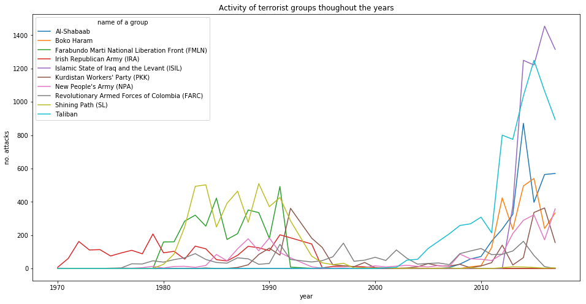

```python
top_groups10=terror[terror['gname'].isin(terror['gname'].value_counts()[1:11].index)]
top_groups10
top_groups10 = pd.crosstab(top_groups10.year,top_groups10.gname)
top_groups10.plot()
fig = plt.gcf()
fig.set_size_inches(16,8)
plt.ylabel('no. attacks')
plt.legend(title='name of a group')
plt.title('Activity of terrorist groups thoughout the years')
```